# Multi-Class Image Classification Deep Learning Model for Colorectal Cancer Histology Using TensorFlow Take 3

### December 1, 2020

Template Credit: Adapted from a template made available by Dr. Jason Brownlee of Machine Learning Mastery. [https://machinelearningmastery.com/]

SUMMARY: This project aims to construct a predictive model using a TensorFlow convolutional neural network (CNN) and document the end-to-end steps using a template. The Colorectal Cancer Histology dataset is a multi-class classification situation where we attempt to predict one of several (more than two) possible outcomes.

From iteration Take1, we constructed a few simple three-layer CNN's to model the dataset. We plan to use the best result as the baseline model for future modeling iterations.

From iteration Take2, we constructed a simple VGG convolutional network with six VGG blocks to model the dataset. We also compared the best result from the VGG network with the baseline model from iteration Take1.

In this Take3 iteration, we will construct a VGG-16 convolutional network to model the dataset. We will compare the best result from the network with the baseline model from iteration Take1.

INTRODUCTION: This data set represents a collection of textures in histological images of human colorectal cancer. All images are RGB, 0.495 µm per pixel, digitized with an Aperio ScanScope (Aperio/Leica biosystems), magnification 20x. The histological samples contain fully anonymized images of formalin-fixed paraffin-embedded human colorectal adenocarcinomas (primary tumors) from our pathology archive (Institute of Pathology, University Medical Center Mannheim, Heidelberg University, Mannheim, Germany).

ANALYSIS: From iteration Take1, the baseline model's performance achieved an accuracy score of 98.25% after 15 epochs using the training dataset. After tuning the hyperparameters, the best model processed the validation dataset with an accuracy score of 84.00%.

From iteration Take2, the model's performance achieved an accuracy score of 96.88% after 20 epochs using the training dataset. After tuning the hyperparameters, the best model processed the validation dataset with an accuracy score of 82.30%.

In this Take3 iteration, the model's performance achieved an accuracy score of 99.75% after 30 epochs using the training dataset. After tuning the hyperparameters, the best model processed the validation dataset with an accuracy score of 83.90%.

CONCLUSION: In this iteration, the TensorFlow CNN model appeared to be suitable for modeling this dataset. We should consider experimenting with TensorFlow for further modeling.

Dataset Used: Colorectal Cancer Histology Dataset, Kather JN, Weis CA, Bianconi F, Melchers SM, Schad LR, Gaiser T, Marx A, Zollner F: Multi-class texture analysis in colorectal cancer histology (2016), Scientific Reports (in press)

Dataset ML Model: Multi-class image classification with numerical attributes

Dataset Reference: https://zenodo.org/record/53169#.XGZemKwzbmG

One potential source of performance benchmarks: https://www.kaggle.com/kmader/colorectal-histology-mnist

A deep-learning image classification project generally can be broken down into five major tasks:

1. Prepare Environment
2. Load and Prepare Images
3. Define and Train Models
4. Evaluate and Optimize Models
5. Finalize Model and Make Predictions

# Task 1 - Prepare Environment

```python
# Install the packages to support accessing environment variable and SQL databases
!pip install python-dotenv PyMySQL
```

```
     |████████████████████████████████| 51kB 1.7MB/s
```

```python
# Retrieve GPU configuration information from Colab
gpu_info = !nvidia-smi
gpu_info = '\n'.join(gpu_info)
if gpu_info.find('failed') >= 0:
    print('Select the Runtime → "Change runtime type" menu to enable a GPU accelerator, ')
    print('and then re-execute this cell.')
else:
    print(gpu_info)
```

```
Mon Nov 23 20:09:53 2020
+-----------------------------------------------------------------------------+
| NVIDIA-SMI 455.38       Driver Version: 418.67       CUDA Version: 10.1     |
|-------------------------------+----------------------+----------------------+
| GPU  Name        Persistence-M| Bus-Id        Disp.A | Volatile Uncorr. ECC |
| Fan  Temp  Perf  Pwr:Usage/Cap|         Memory-Usage | GPU-Util  Compute M. |
|                               |                      |               MIG M. |
|===============================+======================+======================|
|   0  Tesla P100-PCIE...  Off  | 00000000:00:04.0 Off |                    0 |
| N/A   44C    P0    29W / 250W |      0MiB / 16280MiB |      0%      Default |
|                               |                      |                 ERR! |
+-------------------------------+----------------------+----------------------+

+-----------------------------------------------------------------------------+
| Processes:                                                                  |
|  GPU   GI   CI        PID   Type   Process name                  GPU Memory |
|        ID   ID                                                   Usage      |
|=============================================================================|
|  No running processes found                                                 |
+-----------------------------------------------------------------------------+
```

```python
# Retrieve memory configuration information from Colab
from psutil import virtual_memory
ram_gb = virtual_memory().total / 1e9
print('Your runtime has {:.1f} gigabytes of available RAM\n'.format(ram_gb))

if ram_gb < 20:
    print('To enable a high-RAM runtime, select the Runtime → "Change runtime type"')
    print('menu, and then select High-RAM in the Runtime shape dropdown. Then, ')
    print('re-execute this cell.')
else:
    print('You are using a high-RAM runtime!')
```

```
Your runtime has 13.7 gigabytes of available RAM

To enable a high-RAM runtime, select the Runtime → "Change runtime type"
menu, and then select High-RAM in the Runtime shape dropdown. Then,
re-execute this cell.
```

```python
# Retrieve CPU information from the system
ncpu = !nproc
print("The number of available CPUs is:", ncpu[0])
```

```
The number of available CPUs is: 2
```

## 1.a) Load libraries and modules

```python
# Set the random seed number for reproducible results
seedNum = 888
```

```python
# Load libraries and packages
import random
random.seed(seedNum)
import numpy as np
np.random.seed(seedNum)
import pandas as pd
import matplotlib.pyplot as plt
import matplotlib.image as mpimg
import os
import sys
# import boto3
# import zipfile
from datetime import datetime
from dotenv import load_dotenv
from sklearn.metrics import accuracy_score
from sklearn.metrics import confusion_matrix
from sklearn.metrics import classification_report
import tensorflow as tf
tf.random.set_seed(seedNum)
from tensorflow import keras
from tensorflow.keras.preprocessing.image import ImageDataGenerator
from tensorflow.keras.callbacks import ReduceLROnPlateau
```

## 1.b) Set up the controlling parameters and functions

```python
# Begin the timer for the script processing
startTimeScript = datetime.now()

# Set up the number of CPU cores available for multi-thread processing
n_jobs = 1

# Set up the flag to stop sending progress emails (setting to True will send status emails!)
notifyStatus = False

# Set Pandas options
pd.set_option("display.max_rows", None)
pd.set_option("display.max_columns", None)
pd.set_option("display.width", 140)

# Set the percentage sizes for splitting the dataset
test_set_size = 0.2
VAL_SET_SIZE = 0.2

# Set various default modeling parameters
default_loss = 'categorical_crossentropy'
default_metrics = ['accuracy']
default_optimizer = tf.keras.optimizers.RMSprop(learning_rate=0.001)
default_kernel_init = tf.keras.initializers.RandomNormal(seed=seedNum)
EPOCH_NUMBER = 30
BATCH_SIZE = 32
# VGG16 expects the size of 224x224x3
IMAGE_SIZE = (224, 224)
input_image_shape = (224, 224, 3)
num_classes = 8

# Define the labels to use for graphing the data
train_metric = "accuracy"
validation_metric = "val_accuracy"
train_loss = "loss"
validation_loss = "val_loss"

# Check the number of GPUs accessible through TensorFlow
print('Num GPUs Available:', len(tf.config.list_physical_devices('GPU')))

# Print out the TensorFlow version for confirmation
print('TensorFlow version:', tf.__version__)
```

```
Num GPUs Available: 1
TensorFlow version: 2.3.0
```

```python
# Set up the parent directory location for loading the dotenv files
# useColab = True
# if useColab:
#     # Mount Google Drive locally for storing files
#     from google.colab import drive
#     drive.mount('/content/gdrive')
#     gdrivePrefix = '/content/gdrive/My Drive/Colab_Downloads/'
#     env_path = '/content/gdrive/My Drive/Colab Notebooks/'
#     dotenv_path = env_path + "python_script.env"
#     load_dotenv(dotenv_path=dotenv_path)

# Set up the dotenv file for retrieving environment variables
# useLocalPC = True
# if useLocalPC:
#     env_path = "/Users/david/PycharmProjects/"
#     dotenv_path = env_path + "python_script.env"
#     load_dotenv(dotenv_path=dotenv_path)
```

```python
# Set up the email notification function
def status_notify(msg_text):
    access_key = os.environ.get('SNS_ACCESS_KEY')
    secret_key = os.environ.get('SNS_SECRET_KEY')
    aws_region = os.environ.get('SNS_AWS_REGION')
    topic_arn = os.environ.get('SNS_TOPIC_ARN')
    if (access_key is None) or (secret_key is None) or (aws_region is None):
        sys.exit("Incomplete notification setup info. Script Processing Aborted!!!")
    sns = boto3.client('sns', aws_access_key_id=access_key, aws_secret_access_key=secret_key, region_name=aws_region)
    response = sns.publish(TopicArn=topic_arn, Message=msg_text)
    if response['ResponseMetadata']['HTTPStatusCode'] != 200 :
        print('Status notification not OK with HTTP status code:', response['ResponseMetadata']['HTTPStatusCode'])
```

```python
if notifyStatus: status_notify('(TensorFlow Multi-Class) Task 1 - Prepare Environment has begun on ' + datetime.now().strftime('%A %B %d, %Y %I:%M:%S %p'))
```

```python
# Reset the random number generators
def reset_random(x):
    random.seed(x)
    np.random.seed(x)
    tf.random.set_seed(x)
```

```python
if notifyStatus: status_notify('(TensorFlow Multi-Class) Task 1 - Prepare Environment completed on ' + datetime.now().strftime('%A %B %d, %Y %I:%M:%S %p'))
```

# Task 2 - Load and Prepare Images

```python
if notifyStatus: status_notify('(TensorFlow Multi-Class) Task 2 - Load and Prepare Images has begun on ' + datetime.now().strftime('%A %B %d, %Y %I:%M:%S %p'))
```

```python
# Clean up the old files and download directories before receiving new ones
!rm -rf staging/
```

```python
staging_dir = 'staging/'
!mkdir staging/
```

```python
data_dir = keras.utils.get_file(
    'Kather_texture_2016_image_tiles_5000.zip',
    'https://dainesanalytics.com/datasets/tensorflow-colorectal-cancer-histology/Kather_texture_2016_image_tiles_5000.zip',
    cache_subdir='/content/staging',
    extract=True)
```

```
Downloading data from https://dainesanalytics.com/datasets/tensorflow-colorectal-cancer-histology/Kather_texture_2016_image_tiles_5000.zip
```

```python
data_dir = 'staging/Kather_texture_2016_image_tiles_5000/'
class1_name = '01_TUMOR'
class2_name = '02_STROMA'
class3_name = '03_COMPLEX'
class4_name = '04_LYMPHO'
class5_name = '05_DEBRIS'
class6_name = '06_MUCOSA'
class7_name = '07_ADIPOSE'
class8_name = '08_EMPTY'
```

```python
# Brief listing of training image files for class 1
training_class1_dir = os.path.join(data_dir, class1_name)
training_class1_files = os.listdir(training_class1_dir)
print('Number of training images for', class1_name, ':', len(os.listdir(training_class1_dir)))
print('Training samples for', class1_name, ':', training_class1_files[:10])

# Brief listing of training image files for class 2
training_class2_dir = os.path.join(data_dir, class2_name)
training_class2_files = os.listdir(training_class2_dir)
print('Number of training images for', class2_name, ':', len(os.listdir(training_class2_dir)))
print('Training samples for', class2_name, ':', training_class2_files[:10])

# Brief listing of training image files for class 3
training_class3_dir = os.path.join(data_dir, class3_name)
training_class3_files = os.listdir(training_class3_dir)
print('Number of training images for', class3_name, ':', len(os.listdir(training_class3_dir)))
print('Training samples for', class3_name, ':', training_class3_files[:10])

training_class4_dir = os.path.join(data_dir, class4_name)
training_class4_files = os.listdir(training_class4_dir)
print('Number of training images for', class4_name, ':', len(os.listdir(training_class4_dir)))
print('Training samples for', class4_name, ':', training_class4_files[:10])

training_class5_dir = os.path.join(data_dir, class5_name)
training_class5_files = os.listdir(training_class5_dir)
print('Number of training images for', class5_name, ':', len(os.listdir(training_class5_dir)))
print('Training samples for', class5_name, ':', training_class5_files[:10])

training_class6_dir = os.path.join(data_dir, class6_name)
training_class6_files = os.listdir(training_class6_dir)
print('Number of training images for', class6_name, ':', len(os.listdir(training_class6_dir)))
print('Training samples for', class6_name, ':', training_class6_files[:10])

training_class7_dir = os.path.join(data_dir, class7_name)
training_class7_files = os.listdir(training_class7_dir)
print('Number of training images for', class7_name, ':', len(os.listdir(training_class7_dir)))
print('Training samples for', class7_name, ':', training_class7_files[:10])

training_class8_dir = os.path.join(data_dir, class8_name)
training_class8_files = os.listdir(training_class8_dir)
print('Number of training images for', class8_name, ':', len(os.listdir(training_class8_dir)))
print('Training samples for', class8_name, ':', training_class8_files[:10])
```

```
Number of training images for 01_TUMOR : 625
Training samples for 01_TUMOR : ['15B66_CRC-Prim-HE-03_009.tif_Row_601_Col_301.tif', '317A_CRC-Prim-HE-06_009.tif_Row_151_Col_1.tif', '17811_CRC-Prim-HE-07_006.tif_Row_301_Col_1.tif', '8113_CRC-Prim-HE-09_024.tif_Row_751_Col_1.tif', '9D87_CRC-Prim-HE-09_025.tif_Row_151_Col_1.tif', '100B0_CRC-Prim-HE…
Number of training images for 02_STROMA : 625
Training samples for 02_STROMA : ['11BF1_CRC-Prim-HE-04.tif_Row_301_Col_301.tif', '14485_CRC-Prim-HE-04_013.tif_Row_1351_Col_151.tif', '14756_CRC-Prim-HE-01_018.tif_Row_901_Col_751.tif', '1196_CRC-Prim-HE-07_014.tif_Row_1051_Col_2401.tif', '12E31_CRC-Prim-HE-02_029.tif_Row_1_Col_301.tif', '12C1E_CRC…
Number of training images for 03_COMPLEX : 625
Training samples for 03_COMPLEX : ['10566_CRC-Prim-HE-06_006.tif_Row_1_Col_1.tif', '18228_CRC-Prim-HE-01_034.tif_Row_301_Col_151.tif', '3201_CRC-Prim-HE-05_019.tif_Row_1_Col_1.tif', '139D0_CRC-Prim-HE-01_048.tif_Row_1_Col_1.tif', '77F2_CRC-Prim-HE-05_012.tif_Row_1_Col_601.tif', '18004_CRC-Prim-HE-06…
Number of training images for 04_LYMPHO : 625
Training samples for 04_LYMPHO : ['18D7_CRC-Prim-HE-09_005.tif_Row_1_Col_1.tif', '9715_CRC-Prim-HE-01.tif_Row_1_Col_1.tif', '733A_CRC-Prim-HE-01_029.tif_Row_151_Col_1.tif', '16837_CRC-Prim-HE-06.tif_Row_301_Col_451.tif', 'D583_CRC-Prim-HE-02_copy.tif_Row_1_Col_1.tif', '1331C_CRC-Prim-HE-01_004.tif_R…
Number of training images for 05_DEBRIS : 625
Training samples for 05_DEBRIS : ['120B2_CRC-Prim-HE-03_014.tif_Row_451_Col_1351.tif', '1336D_CRC-Prim-HE-04_002.tif_Row_151_Col_601.tif', '175D9_CRC-Prim-HE-08_023.tif_Row_1_Col_751.tif', '14779_CRC-Prim-HE-03_029.tif_Row_451_Col_1.tif', '11A91_CRC-Prim-HE-04_012.tif_Row_1_Col_301.tif', '447_CRC-Pr…
Number of training images for 06_MUCOSA : 625
Training samples for 06_MUCOSA : ['15329_CRC-Prim-HE-08_022.tif_Row_751_Col_1351.tif', '14694_CRC-Prim-HE-07_001.tif_Row_301_Col_1351.tif', '12B73_CRC-Prim-HE-06_001.tif_Row_1_Col_601.tif', '26D2_CRC-Prim-HE-08_025.tif_Row_1801_Col_151.tif', '13B48_CRC-Prim-HE-09_001.tif_Row_1501_Col_1051.tif', '14B…
Number of training images for 07_ADIPOSE : 625
Training samples for 07_ADIPOSE : ['163B8_CRC-Prim-HE-03_012.tif_Row_301_Col_601.tif', '16193_CRC-Prim-HE-05_032.tif_Row_751_Col_2101.tif', '144BB_CRC-Prim-HE-04_036.tif_Row_1051_Col_1351.tif', '14E6_CRC-Prim-HE-07.tif_Row_1051_Col_1501.tif', '14B5F_CRC-Prim-HE-10_020.tif_Row_751_Col_1201.tif', '10B…
Number of training images for 08_EMPTY : 625
Training samples for 08_EMPTY : ['132FC_CRC-Prim-HE-06_005.tif_Row_5401_Col_2251.tif', '13AB6_CRC-Prim-HE-06_005.tif_Row_4051_Col_8101.tif', '11C40_CRC-Prim-HE-06_005.tif_Row_6451_Col_1801.tif', '13B69_CRC-Prim-HE-06_005.tif_Row_1051_Col_7651.tif', '10CEA_CRC-Prim-HE-06_005.tif_Row_6301_Col_3751.tif…
```

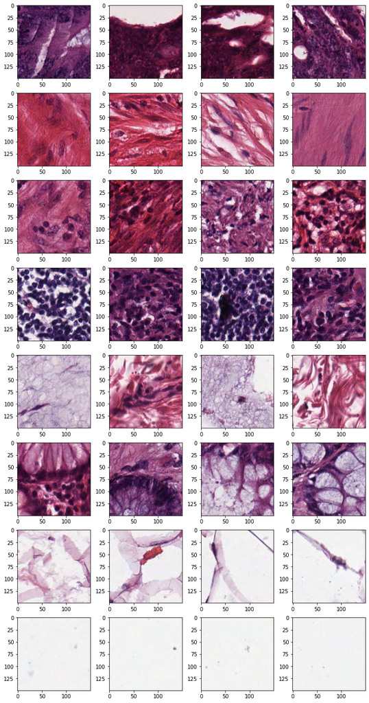

```python
# Plot some training images from the dataset
nrows = 8
ncols = 4

# Set up matplotlib fig, and size it to fit 4x4 pics
fig = plt.gcf()
fig.set_size_inches(ncols * 3, nrows * 3)

reset_random(seedNum)
number_elements = ncols
random_training_class1 = random.sample(training_class1_files, number_elements)
random_training_class2 = random.sample(training_class2_files, number_elements)
random_training_class3 = random.sample(training_class3_files, number_elements)
random_training_class4 = random.sample(training_class4_files, number_elements)
random_training_class5 = random.sample(training_class5_files, number_elements)
random_training_class6 = random.sample(training_class6_files, number_elements)
random_training_class7 = random.sample(training_class7_files, number_elements)
random_training_class8 = random.sample(training_class8_files, number_elements)
next_class1 = [os.path.join(training_class1_dir, fname) for fname in random_training_class1]
next_class2 = [os.path.join(training_class2_dir, fname) for fname in random_training_class2]
next_class3 = [os.path.join(training_class3_dir, fname) for fname in random_training_class3]
next_class4 = [os.path.join(training_class4_dir, fname) for fname in random_training_class4]
next_class5 = [os.path.join(training_class5_dir, fname) for fname in random_training_class5]
next_class6 = [os.path.join(training_class6_dir, fname) for fname in random_training_class6]
next_class7 = [os.path.join(training_class7_dir, fname) for fname in random_training_class7]
next_class8 = [os.path.join(training_class8_dir, fname) for fname in random_training_class8]

for i, img_path in enumerate(next_class1 + next_class2 + next_class3 + next_class4 + next_class5 + next_class6 + next_class7 + next_class8):
    # Set up subplot; subplot indices start at 1
    sp = plt.subplot(nrows, ncols, i + 1)
#     sp.axis('Off')
    img = mpimg.imread(img_path)
    plt.imshow(img)
plt.show()
```

```python
datagen_kwargs = dict(featurewise_center=True, validation_split=VAL_SET_SIZE)
dataflow_kwargs = dict(target_size=IMAGE_SIZE, batch_size=BATCH_SIZE, class_mode='categorical')

print('Loading and pre-processing the validation images...')
validation_datagen = ImageDataGenerator(**datagen_kwargs)
validation_datagen.mean = [123.68, 116.779, 103.939]
validation_generator = validation_datagen.flow_from_directory(data_dir, subset="validation", shuffle=False, **dataflow_kwargs)
print('Number of image batches per epoch of modeling:', len(validation_generator))

do_data_augmentation = False
if do_data_augmentation:
    training_datagen = ImageDataGenerator(
        rotation_range=45,
        horizontal_flip=True,
        vertical_flip=True,
        width_shift_range=0.2,
        height_shift_range=0.2,
        shear_range=0.2,
        zoom_range=0.2,
        **datagen_kwargs)
else:
    training_datagen = validation_datagen

print('\nLoading and pre-processing the training images...')
training_generator = training_datagen.flow_from_directory(data_dir, subset="training", shuffle=True, **dataflow_kwargs)
print('Number of image batches per epoch of modeling:', len(training_generator))
```

```
Loading and pre-processing the validation images...
Found 1000 images belonging to 8 classes.
Number of image batches per epoch of modeling: 32

Loading and pre-processing the training images...
Found 4000 images belonging to 8 classes.
Number of image batches per epoch of modeling: 125
```

```python
if notifyStatus: status_notify('(TensorFlow Multi-Class) Task 2 - Load and Prepare Images completed on ' + datetime.now().strftime('%A %B %d, %Y %I:%M:%S %p'))
```

# Task 3 - Define and Train Models

```python
if notifyStatus: status_notify('(TensorFlow Multi-Class) Task 3 - Define and Train Models has begun on ' + datetime.now().strftime('%A %B %d, %Y %I:%M:%S %p'))
```

```python
# Define the function for plotting training results for comparison
def plot_metrics(history):
    fig, axs = plt.subplots(1, 2, figsize=(24, 15))
    metrics =  [train_loss, train_metric]
    for n, metric in enumerate(metrics):
        name = metric.replace("_"," ").capitalize()
        plt.subplot(2,2,n+1)
        plt.plot(history.epoch, history.history[metric], color='blue', label='Train')
        plt.plot(history.epoch, history.history['val_'+metric], color='red', linestyle="--", label='Val')
        plt.xlabel('Epoch')
        plt.ylabel(name)
        plt.legend()
```

```python
# Define the baseline model for benchmarking
def create_nn_model(input_param=input_image_shape, output_param=num_classes, opt_param=default_optimizer, init_param=default_kernel_init):
    nn_model = keras.applications.VGG16(include_top=True, weights=None, input_shape=input_param, classes=output_param)
    nn_model.compile(loss=default_loss, optimizer=opt_param, metrics=default_metrics)
    return nn_model
```

```python
# Initialize the neural network model and get the training results for plotting graph
startTimeModule = datetime.now()
learning_rate_reduction = ReduceLROnPlateau(monitor='val_accuracy', patience=2, verbose=1, factor=0.5, min_lr=0.00001)
reset_random(seedNum)
nn_model_0 = create_nn_model()
nn_model_history = nn_model_0.fit(
    training_generator,
    steps_per_epoch=len(training_generator),
	validation_data=validation_generator,
    validation_steps=len(validation_generator),
    epochs=EPOCH_NUMBER,
    callbacks=[learning_rate_reduction],
    verbose=1)
print('Total time for model fitting:', (datetime.now() - startTimeModule))
```

```
Epoch 00003: ReduceLROnPlateau reducing learning rate to 0.0005000000237487257.
Epoch 00008: ReduceLROnPlateau reducing learning rate to 0.0002500000118743628.
Epoch 00013: ReduceLROnPlateau reducing learning rate to 0.0001250000059371814.
Epoch 00016: ReduceLROnPlateau reducing learning rate to 6.25000029685907e-05.
Epoch 00018: ReduceLROnPlateau reducing learning rate to 3.125000148429535e-05.
Epoch 00020: ReduceLROnPlateau reducing learning rate to 1.5625000742147677e-05.
Epoch 00022: ReduceLROnPlateau reducing learning rate to 1e-05.
Total time for model fitting: 0:15:59.813946
```

```python
nn_model_0.summary()
```

```
Model: "vgg16"
_________________________________________________________________
Layer (type)                 Output Shape              Param #
=================================================================
input_1 (InputLayer)         [(None, 224, 224, 3)]     0
_________________________________________________________________
block1_conv1 (Conv2D)        (None, 224, 224, 64)      1792
_________________________________________________________________
block1_conv2 (Conv2D)        (None, 224, 224, 64)      36928
_________________________________________________________________
block1_pool (MaxPooling2D)   (None, 112, 112, 64)      0
_________________________________________________________________
block2_conv1 (Conv2D)        (None, 112, 112, 128)     73856
_________________________________________________________________
block2_conv2 (Conv2D)        (None, 112, 112, 128)     147584
_________________________________________________________________
block2_pool (MaxPooling2D)   (None, 56, 56, 128)       0
_________________________________________________________________
block3_conv1 (Conv2D)        (None, 56, 56, 256)       295168
_________________________________________________________________
block3_conv2 (Conv2D)        (None, 56, 56, 256)       590080
_________________________________________________________________
block3_conv3 (Conv2D)        (None, 56, 56, 256)       590080
_________________________________________________________________
block3_pool (MaxPooling2D)   (None, 28, 28, 256)       0
_________________________________________________________________
block4_conv1 (Conv2D)        (None, 28, 28, 512)       1180160
_________________________________________________________________
block4_conv2 (Conv2D)        (None, 28, 28, 512)       2359808
_________________________________________________________________
block4_conv3 (Conv2D)        (None, 28, 28, 512)       2359808
_________________________________________________________________
block4_pool (MaxPooling2D)   (None, 14, 14, 512)       0
_________________________________________________________________
block5_conv1 (Conv2D)        (None, 14, 14, 512)       2359808
_________________________________________________________________
block5_conv2 (Conv2D)        (None, 14, 14, 512)       2359808
_________________________________________________________________
block5_conv3 (Conv2D)        (None, 14, 14, 512)       2359808
_________________________________________________________________
block5_pool (MaxPooling2D)   (None, 7, 7, 512)         0
_________________________________________________________________
flatten (Flatten)            (None, 25088)             0
_________________________________________________________________
fc1 (Dense)                  (None, 4096)              102764544
_________________________________________________________________
fc2 (Dense)                  (None, 4096)              16781312
_________________________________________________________________
predictions (Dense)          (None, 8)                 32776
=================================================================
Total params: 134,293,320
Trainable params: 134,293,320
Non-trainable params: 0
_________________________________________________________________
```

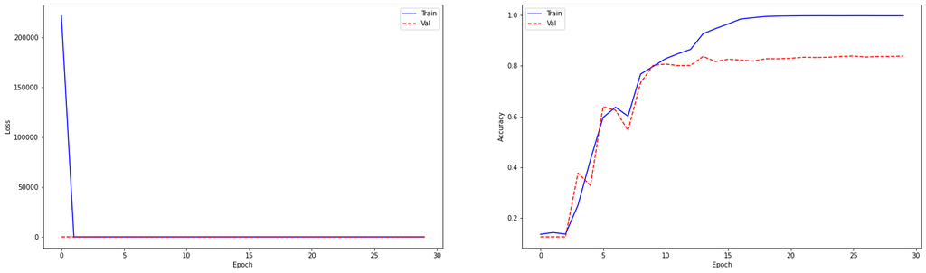

```python
plot_metrics(nn_model_history)
```

```python
if notifyStatus: status_notify('(TensorFlow Multi-Class) Task 3 - Define and Train Models completed on ' + datetime.now().strftime('%A %B %d, %Y %I:%M:%S %p'))
```

# Task 4 - Evaluate and Optimize Models

```python
if notifyStatus: status_notify('(TensorFlow Multi-Class) Task 4 - Evaluate and Optimize Models has begun on ' + datetime.now().strftime('%A %B %d, %Y %I:%M:%S %p'))
```

```python
# Not applicable for this iteration of modeling
```

```python
if notifyStatus: status_notify('(TensorFlow Multi-Class) Task 4 - Evaluate and Optimize Models completed on ' + datetime.now().strftime('%A %B %d, %Y %I:%M:%S %p'))
```

# Task 5 - Finalize Model and Make Predictions

```python
if notifyStatus: status_notify('(TensorFlow Multi-Class) Task 5 - Finalize Model and Make Predictions has begun on ' + datetime.now().strftime('%A %B %d, %Y %I:%M:%S %p'))
```

```python
final_model = nn_model_0

# Print the labels used for the modeling
print(validation_generator.class_indices)
```

```
{'01_TUMOR': 0, '02_STROMA': 1, '03_COMPLEX': 2, '04_LYMPHO': 3, '05_DEBRIS': 4, '06_MUCOSA': 5, '07_ADIPOSE': 6, '08_EMPTY': 7}
```

```python
final_model.evaluate(validation_generator, verbose=1)
```

```
[3.243985652923584, 0.8389999866485596]
```

```python
test_pred = final_model.predict(validation_generator)
test_predictions = np.argmax(test_pred, axis=-1)
test_original = validation_generator.labels
print('Accuracy Score:', accuracy_score(test_original, test_predictions))
print(confusion_matrix(test_original, test_predictions))
print(classification_report(test_original, test_predictions))
```

```
Accuracy Score: 0.839
[[111   1   4   3   0   6   0   0]
 [  0  82  21   0  22   0   0   0]
 [  5  20  89   5   2   4   0   0]
 [  4   1  10 110   0   0   0   0]
 [  0  17   3   0 100   4   1   0]
 [ 13   0   2   0   4 106   0   0]
 [  0   0   0   0   5   0 117   3]
 [  0   0   0   0   0   0   1 124]]
              precision    recall  f1-score   support

           0       0.83      0.89      0.86       125
           1       0.68      0.66      0.67       125
           2       0.69      0.71      0.70       125
           3       0.93      0.88      0.91       125
           4       0.75      0.80      0.78       125
           5       0.88      0.85      0.87       125
           6       0.98      0.94      0.96       125
           7       0.98      0.99      0.98       125

    accuracy                           0.84      1000
   macro avg       0.84      0.84      0.84      1000
weighted avg       0.84      0.84      0.84      1000
```

```python
if notifyStatus: status_notify('(TensorFlow Multi-Class) Task 5 - Finalize Model and Make Predictions completed on ' + datetime.now().strftime('%A %B %d, %Y %I:%M:%S %p'))
```

```python
print ('Total time for the script:',(datetime.now() - startTimeScript))
```

```
Total time for the script: 0:16:19.622524
```